# Practical Machine Learning: course project

Maarten Elen

30 Jan 2016

```r
setwd( "/Users/maartenelen/Documents/Modeling/Johns Hopkins Coursera/course 8")
set.seed(123456)
library("dplyr")
library("caret")
testing_pml <- read.csv("~/Documents/Modeling/Johns Hopkins Coursera/course 8/pml-testing.csv")
training_pml <- read.csv("~/Documents/Modeling/Johns Hopkins Coursera/course 8/pml-training.csv")
```

First, let’s set aside some data to be able to estimate our out-of-sample error, when building our model. We’ll use the dataset “training” to build our model and the dataset “CV” to test our out-of-sample error.

```r
in_train <- createDataPartition(training_pml$classe, p=0.7, list=FALSE)
training <- training_pml[in_train, ]
CV <- training_pml[-in_train, ]
```

*EXPLORATORY ANALYSIS*

Now, let’s do some exploratory analysis. First let’s have a look at which variables relate most strongly to our class variable. In fact, it looks like the timestamps are the most important predictors of class. It appears that respondents where asked to sequentially do the exercise in different ways. This means that if we know the timestamp and who did the exercise, we can find out how they did the exercise. This is not a very useful approach for future applications, but since the goal of the assignment is to “predict the manner in which they did the exercise” by using “any of the other variables to predict with”, let’s see what we get!

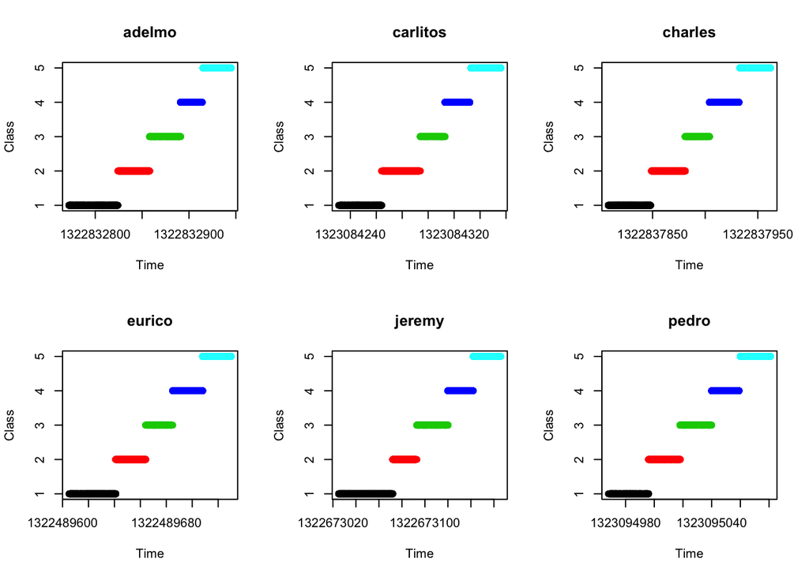

```r
usernames <- levels(training$user_name)

par(mfrow=c(2,3))
for (i in 1:length(usernames)) {
      x <- training[training$user_name == usernames[i],]
      plot(x$raw_timestamp_part_1,
           x$classe,
           col=x$classe,
           xlab="Time",
           ylab="Class",
           main=usernames[i])
}
```

*MODEL TESTING*

*MODEL 1*

Let’s train a decision tree model with time and user as predictors of class. Let’s train it on our training set and then test our accuracy on the CV set.

```r
fit1 <- train(classe~raw_timestamp_part_1+user_name, method="rpart", data=training)
predictions <- predict(fit1, CV)
confusionMatrix(predictions, CV$classe)
```

```
## Confusion Matrix and Statistics
##
##           Reference
## Prediction    A    B    C    D    E
##          A 1663    4    0    0    0
##          B   11 1128    4    0    0
##          C    0    7 1011    3    0
##          D    0    0   11  955    1
##          E    0    0    0    6 1081
##
## Overall Statistics
##
##                Accuracy : 0.992
##                  95% CI : (0.9894, 0.9941)
##     No Information Rate : 0.2845
##     P-Value [Acc > NIR] : < 2.2e-16
##
##                   Kappa : 0.9899
##  Mcnemar's Test P-Value : NA
##
## Statistics by Class:
##
##                      Class: A Class: B Class: C Class: D Class: E
## Sensitivity            0.9934   0.9903   0.9854   0.9907   0.9991
## Specificity            0.9991   0.9968   0.9979   0.9976   0.9988
## Pos Pred Value         0.9976   0.9869   0.9902   0.9876   0.9945
## Neg Pred Value         0.9974   0.9977   0.9969   0.9982   0.9998
## Prevalence             0.2845   0.1935   0.1743   0.1638   0.1839
## Detection Rate         0.2826   0.1917   0.1718   0.1623   0.1837
## Detection Prevalence   0.2833   0.1942   0.1735   0.1643   0.1847
## Balanced Accuracy      0.9962   0.9936   0.9917   0.9941   0.9989
```

This gives us a model with 99% accuracy!

*MODEL 2*

Since the above model isn’t very useful for future applications, let’s also take a look at some other models, without making use of the timestamps. First let’s filter out variables with missing values (e.g. the calculated variables). Let’s also filter out the timestamp data and identifier variables. Let’s only have a look at the sensor data this time.

```r
filter <- apply(training, 2, function(x) {sum(is.na(x) | x == "")})
filter <- ifelse(filter == 0, TRUE, FALSE)
filter[[1]] <- FALSE
filter[[2]] <- FALSE
filter[[3]] <- FALSE
filter[[4]] <- FALSE
filter[[5]] <- FALSE
filter[[6]] <- FALSE
filter[[7]] <- FALSE

ncol <- ncol(training[,filter])
```

This leaves us with 53 features. Let’s build a decision tree with all these features and test our accuracy on our CV set.

```r
fit2 <- train(classe~., method="rpart", data=training[,filter])
predictions <- predict(fit2, CV)
confusionMatrix(predictions, CV$classe)
```

```
## Confusion Matrix and Statistics
##
##           Reference
## Prediction    A    B    C    D    E
##          A 1538  471  486  444  157
##          B   23  386   34  165  158
##          C  109  282  506  355  273
##          D    0    0    0    0    0
##          E    4    0    0    0  494
##
## Overall Statistics
##
##                Accuracy : 0.4969
##                  95% CI : (0.484, 0.5097)
##     No Information Rate : 0.2845
##     P-Value [Acc > NIR] : < 2.2e-16
##
##                   Kappa : 0.3418
##  Mcnemar's Test P-Value : NA
##
## Statistics by Class:
##
##                      Class: A Class: B Class: C Class: D Class: E
## Sensitivity            0.9188  0.33889  0.49318   0.0000  0.45656
## Specificity            0.6300  0.91993  0.79029   1.0000  0.99917
## Pos Pred Value         0.4968  0.50392  0.33180      NaN  0.99197
## Neg Pred Value         0.9512  0.85290  0.88073   0.8362  0.89085
## Prevalence             0.2845  0.19354  0.17434   0.1638  0.18386
## Detection Rate         0.2613  0.06559  0.08598   0.0000  0.08394
## Detection Prevalence   0.5261  0.13016  0.25913   0.0000  0.08462
## Balanced Accuracy      0.7744  0.62941  0.64173   0.5000  0.72786
```

This gives us an accuracy of slightly below 50%. Our model doesn’t really prove to be able to predict the B and D classes. Let’s have a look at what variables are most important in predicting class.

```r
varImp(fit2)
```

```
## rpart variable importance
##
##   only 20 most important variables shown (out of 52)
##
##                   Overall
## pitch_forearm      100.00
## roll_forearm        72.32
## roll_belt           69.33
## magnet_dumbbell_y   48.74
## accel_belt_z        42.49
## yaw_belt            40.64
## magnet_belt_y       40.40
## total_accel_belt    34.99
## accel_arm_x         28.33
## magnet_arm_x        28.28
## roll_dumbbell       18.40
## magnet_dumbbell_x   18.07
## magnet_dumbbell_z   17.83
## accel_dumbbell_y    15.57
## roll_arm            15.12
## gyros_arm_x          0.00
## yaw_forearm          0.00
## gyros_arm_z          0.00
## magnet_belt_z        0.00
## pitch_dumbbell       0.00
```

*MODEL 3*

Let’s build another model with only the 4 most important variables

```r
fit3 <- train(classe~pitch_forearm+roll_forearm+roll_belt+magnet_dumbbell_y, method="rpart", data=training[,filter])
predictions <- predict(fit3, CV)
confusionMatrix(predictions, CV$classe)
```

```
## Confusion Matrix and Statistics
##
##           Reference
## Prediction    A    B    C    D    E
##          A 1538  471  486  444  157
##          B   23  386   34  165  158
##          C  109  282  506  355  273
##          D    0    0    0    0    0
##          E    4    0    0    0  494
##
## Overall Statistics
##
##                Accuracy : 0.4969
##                  95% CI : (0.484, 0.5097)
##     No Information Rate : 0.2845
##     P-Value [Acc > NIR] : < 2.2e-16
##
##                   Kappa : 0.3418
##  Mcnemar's Test P-Value : NA
##
## Statistics by Class:
##
##                      Class: A Class: B Class: C Class: D Class: E
## Sensitivity            0.9188  0.33889  0.49318   0.0000  0.45656
## Specificity            0.6300  0.91993  0.79029   1.0000  0.99917
## Pos Pred Value         0.4968  0.50392  0.33180      NaN  0.99197
## Neg Pred Value         0.9512  0.85290  0.88073   0.8362  0.89085
## Prevalence             0.2845  0.19354  0.17434   0.1638  0.18386
## Detection Rate         0.2613  0.06559  0.08598   0.0000  0.08394
## Detection Prevalence   0.5261  0.13016  0.25913   0.0000  0.08462
## Balanced Accuracy      0.7744  0.62941  0.64173   0.5000  0.72786
```

Seems like our accuracy hasn’t gone down, with this simplified model, so we’ll take this as our new model.

*MODEL 4*

Let’s if we can improve our accuracy with a random forest.

```r
fit4 <- train(classe~pitch_forearm+roll_forearm+roll_belt+magnet_dumbbell_y, method="rf", data=training[,filter])
predictions <- predict(fit4, CV)
confusionMatrix(predictions, CV$classe)
```

```
## Confusion Matrix and Statistics
##
##           Reference
## Prediction    A    B    C    D    E
##          A 1570   35    6    7    7
##          B   14  945   34   17   24
##          C   66   89  947   44   15
##          D   22   59   31  891    6
##          E    2   11    8    5 1030
##
## Overall Statistics
##
##                Accuracy : 0.9147
##                  95% CI : (0.9073, 0.9217)
##     No Information Rate : 0.2845
##     P-Value [Acc > NIR] : < 2.2e-16
##
##                   Kappa : 0.8923
##  Mcnemar's Test P-Value : < 2.2e-16
##
## Statistics by Class:
##
##                      Class: A Class: B Class: C Class: D Class: E
## Sensitivity            0.9379   0.8297   0.9230   0.9243   0.9519
## Specificity            0.9869   0.9812   0.9560   0.9760   0.9946
## Pos Pred Value         0.9662   0.9139   0.8157   0.8831   0.9754
## Neg Pred Value         0.9756   0.9600   0.9833   0.9850   0.9892
## Prevalence             0.2845   0.1935   0.1743   0.1638   0.1839
## Detection Rate         0.2668   0.1606   0.1609   0.1514   0.1750
## Detection Prevalence   0.2761   0.1757   0.1973   0.1715   0.1794
## Balanced Accuracy      0.9624   0.9055   0.9395   0.9501   0.9733
```

Our random forest seems to be much more capable in predicting all classes - even the B and D classes. Its accuracy is about 91% - not as good as our timestamp model, but much more useful!

*PREDICTIONS*

Let’s predict the test cases with two of our models: model 1 and model 4.

```r
predictions_fit1 <- predict(fit1, testing_pml)
predictions_fit4 <- predict(fit4, testing_pml)
confusionMatrix(predictions_fit1, predictions_fit4)
```

```
## Confusion Matrix and Statistics
##
##           Reference
## Prediction A B C D E
##          A 6 0 1 0 0
##          B 0 6 1 1 0
##          C 0 0 1 0 0
##          D 0 0 0 1 0
##          E 0 0 0 0 3
##
## Overall Statistics
##
##                Accuracy : 0.85
##                  95% CI : (0.6211, 0.9679)
##     No Information Rate : 0.3
##     P-Value [Acc > NIR] : 5.427e-07
##
##                   Kappa : 0.7973
##  Mcnemar's Test P-Value : NA
##
## Statistics by Class:
##
##                      Class: A Class: B Class: C Class: D Class: E
## Sensitivity            1.0000   1.0000   0.3333   0.5000     1.00
## Specificity            0.9286   0.8571   1.0000   1.0000     1.00
## Pos Pred Value         0.8571   0.7500   1.0000   1.0000     1.00
## Neg Pred Value         1.0000   1.0000   0.8947   0.9474     1.00
## Prevalence             0.3000   0.3000   0.1500   0.1000     0.15
## Detection Rate         0.3000   0.3000   0.0500   0.0500     0.15
## Detection Prevalence   0.3500   0.4000   0.0500   0.0500     0.15
## Balanced Accuracy      0.9643   0.9286   0.6667   0.7500     1.00
```